# mmselva_6

Exercise 1:

```r
data("faithful")
head(faithful)
```

```
##   eruptions waiting
## 1     3.600      79
## 2     1.800      54
## 3     3.333      74
## 4     2.283      62
## 5     4.533      85
## 6     2.883      55
```

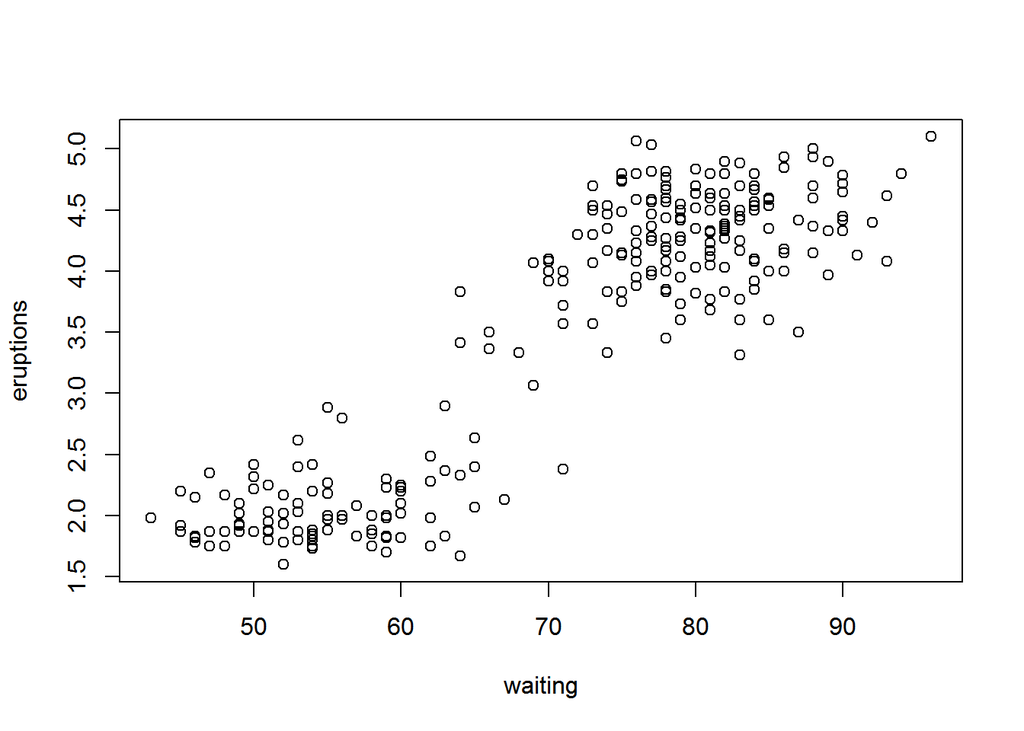

```r
plot(eruptions~waiting, data=faithful)
```

```r
cor(faithful$eruptions, faithful$waiting)
```

```
## [1] 0.9008112
```

We know that the correlation between waiting time and eruption is positive because r (0.9008) is positive, which means that as waiting time between eruptions gets longer then eruption duration gets longer. We also know that the correlation is fairly strong because 0.9008 is closer to 1 than to 0.

End Exercise 1

Exercise 2:

```r
mod1=lm(Temp~Ozone, data=airquality)
summary(mod1)
```

```
##
## Call:
## lm(formula = Temp ~ Ozone, data = airquality)
##
## Residuals:
##     Min      1Q  Median      3Q     Max
## -22.147  -4.858   1.828   4.342  12.328
##
## Coefficients:
##             Estimate Std. Error t value Pr(>|t|)
## (Intercept) 69.41072    1.02971   67.41   <2e-16 ***
## Ozone        0.20081    0.01928   10.42   <2e-16 ***
## ---
## Signif. codes:  0 '***' 0.001 '**' 0.01 '*' 0.05 '.' 0.1 ' ' 1
##
## Residual standard error: 6.819 on 114 degrees of freedom
##   (37 observations deleted due to missingness)
## Multiple R-squared:  0.4877, Adjusted R-squared:  0.4832
## F-statistic: 108.5 on 1 and 114 DF,  p-value: < 2.2e-16
```

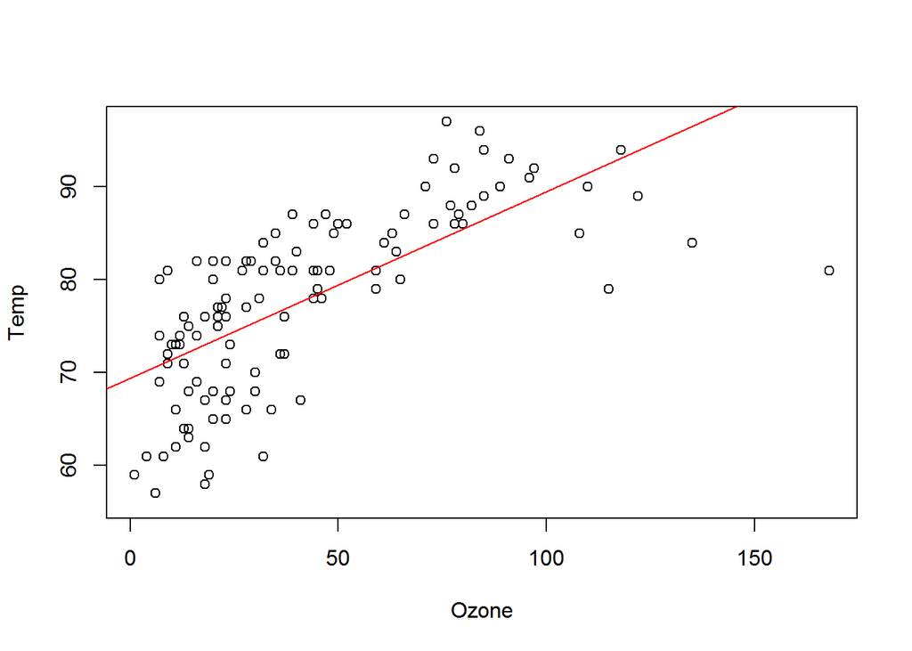

```r
plot(Temp~Ozone, data=airquality)
abline(lm(Temp~Ozone, data=airquality), col="red")
```

The y-intercept is 69.41, which means that when ozone is at 0, the base temperature is 69.41 degrees. The slope is 0.20081, which means that for every increase of 1 in ozone, the temperature increases 0.20081 degrees. The relationship between temperature and ozone is significant because the p-value is very, very small.

```r
mod2=lm(eruptions~waiting, data=faithful)
summary(mod2)
```

```
##
## Call:
## lm(formula = eruptions ~ waiting, data = faithful)
##
## Residuals:
##      Min       1Q   Median       3Q      Max
## -1.29917 -0.37689  0.03508  0.34909  1.19329
##
## Coefficients:
##              Estimate Std. Error t value Pr(>|t|)
## (Intercept) -1.874016   0.160143  -11.70   <2e-16 ***
## waiting      0.075628   0.002219   34.09   <2e-16 ***
## ---
## Signif. codes:  0 '***' 0.001 '**' 0.01 '*' 0.05 '.' 0.1 ' ' 1
##
## Residual standard error: 0.4965 on 270 degrees of freedom
## Multiple R-squared:  0.8115, Adjusted R-squared:  0.8108
## F-statistic:  1162 on 1 and 270 DF,  p-value: < 2.2e-16
```

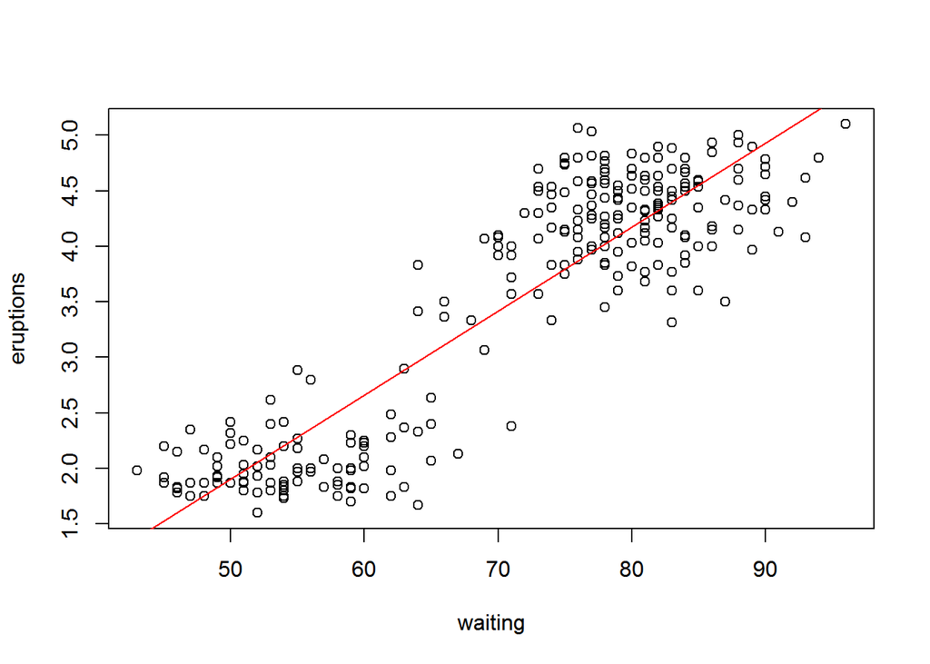

```r
plot(eruptions~waiting, data=faithful)
abline(lm(eruptions~waiting, data=faithful), col="red")
```

The y-intercept is -1.87, which means that when waiting time is at 0 minutes, the base eruption time is -1.87 minuntes. The slope is 0.0756, which means that for every increase of 1 minute in waiting time, the eruption duration increases 0.0756 minutes. The relationship between waiting time and eruption duration is significant because the p-value is very, very small.

END Exercise 2

Exercise 3:

```r
res = residuals(mod1)
RSS = sum(res^2)
RSE = sqrt(RSS/summary(mod1)$df[2])
RSE
```

```
## [1] 6.818914
```

```r
MSE = RSS/summary(mod1)$df[2]
MSE
```

```
## [1] 46.49759
```

END Exercise 3